# Extending Fried & Kievit’s (2016) simulation critiquing Schmaal et al. (2016)

Ian Hussey

19 November, 2024

```r
# dependencies
library(ggplot2)
library(dplyr)
library(tidyr)
library(tibble)
library(purrr)
library(janitor)
library(plotrix) # for std.error
library(knitr)
library(kableExtra)
```

# Visualising effect size reported in Schmaal

Overall sample result in original publication: Cohen’s d = .144, 95% CI [.064, .225]. N control = 7040, N MDD = 1700 (see Schmaal et al., 2016 table 1).

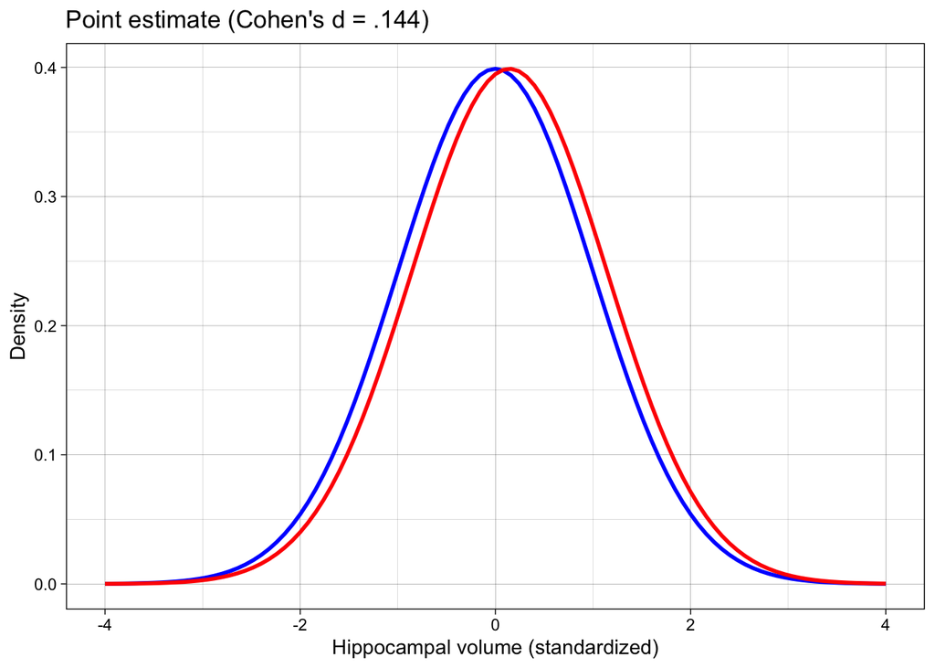

```r
ggplot(data = data.frame(x = c(-4, 4)), aes(x = x)) +
  stat_function(
    fun = dnorm,
    args = list(mean = 0, sd = 1),
    color = "blue",
    size = 1
  ) +
  stat_function(
    fun = dnorm,
    args = list(mean = 0.144, sd = 1),
    color = "red",
    size = 1
  ) +
  labs(
    title = "Point estimate (Cohen's d = .144)",
    x = "Hippocampal volume (standardized)",
    y = "Density"
  ) +
  theme_linedraw()
```

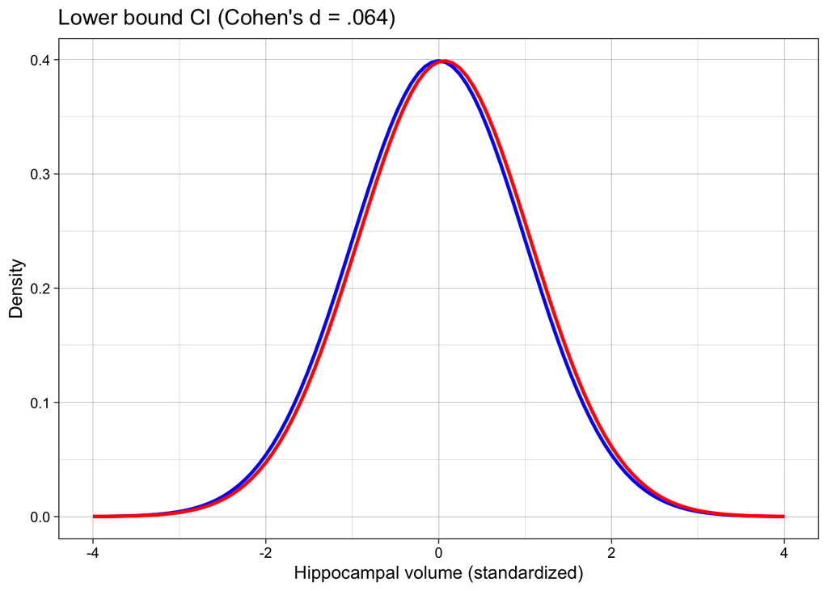

```r
ggplot(data = data.frame(x = c(-4, 4)), aes(x = x)) +
  stat_function(
    fun = dnorm,
    args = list(mean = 0, sd = 1),
    color = "blue",
    size = 1
  ) +
  stat_function(
    fun = dnorm,
    args = list(mean = 0.064, sd = 1),
    color = "red",
    size = 1
  ) +
  labs(
    title = "Lower bound CI (Cohen's d = .064)",
    x = "Hippocampal volume (standardized)",
    y = "Density"
  ) +
  theme_linedraw()
```

[figure not shown]

```r
ggplot(data = data.frame(x = c(-4, 4)), aes(x = x)) +
  stat_function(
    fun = dnorm,
    args = list(mean = 0, sd = 1),
    color = "blue",
    size = 1
  ) +
  stat_function(
    fun = dnorm,
    args = list(mean = 0.225, sd = 1),
    color = "red",
    size = 1
  ) +
  labs(
    title = "Lower bound CI (Cohen's d = .225)",
    x = "Hippocampal volume (standardized)",
    y = "Density"
  ) +
  theme_linedraw()
```

# Simulate classification accuracy implied by Schmaal’s effect size

Fried & Kievit (2016) reported a classification accuracy of 52.6% but using just a single simulated data set and no set seed (i.e. re-running their code produces different results). I therefore replicated their simulation and increased the number of iterations to average over to 1000.

```r
set.seed(42)

generate_data <- function(n_control,
                          n_mdd,
                          population_cohens_d) {

  require(dplyr)
  require(tibble)

  data <-
    bind_rows(
      tibble(condition = "control",
             hippocampal_volume = rnorm(n = n_control, mean = 0, sd = 1)),
      tibble(condition = "mdd",
             hippocampal_volume = rnorm(n = n_mdd, mean = population_cohens_d, sd = 1))
    ) |>
    mutate(condition_numeric = case_when(condition == "control" ~ 1,
                                         condition == "mdd" ~ 2))

  return(data)
}

analyse <- function(data) {

  require(yardstick)
  require(mclust)

  fit <- mclust::Mclust(data = data$hippocampal_volume,
                        G = 2, # two clusters
                        verbose = FALSE)

  classifications <- tibble(truth = factor(data$condition_numeric),
                            estimate = factor(fit$classification))

  res <- yardstick::accuracy(classifications,
                             truth = truth,
                             estimate = estimate) |>
    select(accuracy = .estimate)

  return(res)
}

simulation <-
  # "using the experiment parameters..."
  expand_grid(n_control = 7040,
              n_mdd = 1700,
              population_cohens_d = c(.144, .064, .225),
              iteration = 1:1000) |>

  # ...generate data that meets those parameters...
  mutate(data = pmap(list(n_control,
                          n_mdd,
                          population_cohens_d),
                     generate_data)) |>

  # "... then apply the analysis function to the generated data using the parameters relevant to analysis"
  mutate(results = pmap(list(data),
                        analyse))

# summarize across iterations
simulation_results <- simulation |>
  unnest(results) |>
  group_by(n_control,
           n_mdd,
           population_cohens_d) |>
  summarize(classification_accuracy_mean = mean(accuracy),
            classification_accuracy_se = std.error(accuracy),
            .groups = "drop") |>
  select(n_control, n_mdd, population_cohens_d,
         classification_accuracy_mean,
         classification_accuracy_se)

# print table
simulation_results |>
  mutate_if(is.numeric, round_half_up, digits = 3) |>
  kable(align = "r") |>
  kable_classic(full_width = FALSE)
```

| n_control | n_mdd | population_cohens_d | classification_accuracy_mean | classification_accuracy_se |
| --- | --- | --- | --- | --- |
| 7040 | 1700 | 0.064 | 0.508 | 0.001 |
| 7040 | 1700 | 0.144 | 0.517 | 0.001 |
| 7040 | 1700 | 0.225 | 0.529 | 0.001 |

```r
res_string <- paste0(
  "Classification accuracy = ", simulation_results$classification_accuracy_mean[2] |> round_half_up(3),
  ", 95% CI [", simulation_results$classification_accuracy_mean[1] |> round_half_up(3),
  ", ", simulation_results$classification_accuracy_mean[3] |> round_half_up(3), "]"
)

# res_string
```

Note that [Bartoš et al. (2023)](https://arxiv.org/abs/2310.04153), after flipped coins 350,757 times and found that the probability of a flipped coin landing on the same side has a slight bias: 50.8%. The probability of being able to predict whether a given person has MDD is therefore not merely akin to tossing a coin, it is statistically comparable to it, given the bias of tossed coins.

Cost of just the MRI scans for this study can be roughly estimated at 8159000 CHF.

Citations in 2024/11:

- Schmaal et al. (2016): 1162
- Fried & Kievit (2016): 31